# 重賞レース予測レポート【毎時自動更新中】

作成日時: 2025/11/02 12:04:47

☞ [マニュアル(pdf)](https://ryutoro-galois.github.io/keiba-predictor/manual/manual.pdf)

☞ 過去5年の同一レース結果: [2024年](https://ryutoro-galois.github.io/keiba-predictor/report/PredResult_2024y_raceDate_20241026_20241027.html), [2023年](https://ryutoro-galois.github.io/keiba-predictor/report/PredResult_2023y_raceDate_20231028_20231029.html), [2022年](https://ryutoro-galois.github.io/keiba-predictor/report/PredResult_2022y_raceDate_20221029_20221030.html), [2021年](https://ryutoro-galois.github.io/keiba-predictor/report/PredResult_2021y_raceDate_20211030_20211031.html), [2020年](https://ryutoro-galois.github.io/keiba-predictor/report/PredResult_2020y_raceDate_20201031_20201101.html)

☞ 過去4週間の別レース結果: [1週前(10/25-26)](https://ryutoro-galois.github.io/keiba-predictor/report/PredResult_2025y_raceDate_20251025_20251026.html), [2週前(10/18-19)](https://ryutoro-galois.github.io/keiba-predictor/report/PredResult_2025y_raceDate_20251018_20251019.html), [3週前(10/11-13)](https://ryutoro-galois.github.io/keiba-predictor/report/PredResult_2025y_raceDate_20251011_20251013.html), [4週前(10/5)](https://ryutoro-galois.github.io/keiba-predictor/report/PredResult_2025y_raceDate_20251005_20251005.html)

☞ netkeiba: [ファンタジーステークス(GⅢ)](https://race.netkeiba.com/race/shutuba.html?race_id=202508031011&rf=race_list), [天皇賞(秋)(GⅠ)](https://race.netkeiba.com/race/shutuba.html?race_id=202505041111&rf=race_list)

## 0. 推し馬予測 (AI予測)

### 【ファンタジーステークス(GⅢ) 2025/11/01(土)】

- 本命(◎): 1-3着内確率(勝負強さ)が1位の馬
- 対抗(◯): 1-3着内確率が2-N位(20%程度以上)の中で予測タイムが最も速い馬
- 3番手(▲): 1-3着内確率が2-N位(20%程度以上)のでダークホース確率が最も高い馬
- 穴: ダークホース確率が上位1-M位(40%程度以上)の中で1-3着内確率が最も高い馬

| 推し馬 | 枠番 | 馬番 | 人気 | オッズ | 馬名 | 騎手 | 調教師 | 予測タイム(sec) | 1_順位 | 1-3着内確率(%) | 2_順位 | ﾀﾞｰｸﾎｰｽ確率(%) | 3_順位 |
| --- | --- | --- | --- | --- | --- | --- | --- | --- | --- | --- | --- | --- | --- |
| 本命(◎) | 5 | 5 | 2 | 4.3 | ブラックチャリス | 浜中俊 | 武幸四郎 | 87.2 | 4.0 | 35.1 | 1 | 0.4 | 12 |
| 対抗(◯) | 1 | 1 | 5 | 7.8 | ポペット | 横山典弘 | 高橋康之 | 87.2 | 5.0 | 21.3 | 3 | 1.7 | 8 |
| 3番手(▲) | 5 | 6 | 4 | 7.3 | ベレーバスク | 丹内祐次 | 清水英克 | 87.3 | 12.0 | 20.1 | 4 | 1.5 | 9 |
| 穴 | 3 | 3 | 12 | 107.5 | ナオミライトニング | 北村友一 | 矢作芳人 | 87.2 | 8.5 | 7.7 | 10 | 43.9 | 1 |

### 【天皇賞(秋)(GⅠ) 2025/11/02(日)】

- 本命(◎): 1-3着内確率(勝負強さ)が1位の馬
- 対抗(◯): 1-3着内確率が2-N位(20%程度以上)の中で予測タイムが最も速い馬
- 3番手(▲): 1-3着内確率が2-N位(20%程度以上)のでダークホース確率が最も高い馬
- 穴: ダークホース確率が上位1-M位(40%程度以上)の中で1-3着内確率が最も高い馬

| 推し馬 | 枠番 | 馬番 | 人気 | オッズ | 馬名 | 騎手 | 調教師 | 予測タイム(sec) | 1_順位 | 1-3着内確率(%) | 2_順位 | ﾀﾞｰｸﾎｰｽ確率(%) | 3_順位 |
| --- | --- | --- | --- | --- | --- | --- | --- | --- | --- | --- | --- | --- | --- |
| 本命(◎) | 4 | 5 | 2 | 6.7 | タスティエーラ | Ｄ．レーン | 堀宣行 | 120.0 | 3 | 43.1 | 1 | 0.6 | 12 |
| 対抗(◯) | 5 | 7 | 1 | 2.8 | マスカレードボール | Ｃ．ルメール | 手塚貴久 | 116.1 | 1 | 27.5 | 2 | 0.6 | 11 |
| 3番手(▲) | 4 | 6 | 5 | 8.9 | ブレイディヴェーグ | 戸崎圭太 | 宮田敬介 | 120.3 | 4 | 20.4 | 3 | 1.8 | 7 |
| 穴 | 3 | 4 | 12 | 43.6 | ソールオリエンス | 丹内祐次 | 手塚貴久 | 119.5 | 2 | 19.9 | 4 | 62.9 | 1 |

## 1. 予測チャート (タイム/勝負強さ)

### 【ファンタジーステークス(GⅢ)】

2025/11/01(土), 08_京都, 芝右外1400m

[interactive chart not shown]

### 【天皇賞(秋)(GⅠ)】

2025/11/02(日), 05_東京, 芝左2000m

[interactive chart not shown]

## 2. オッズモニタリング (毎時)

### 【ファンタジーステークス】

[interactive chart not shown]

### 【天皇賞(秋)】

[interactive chart not shown]

## 3. 出馬表

### 【ファンタジーステークス 2025/11/01(土) 】

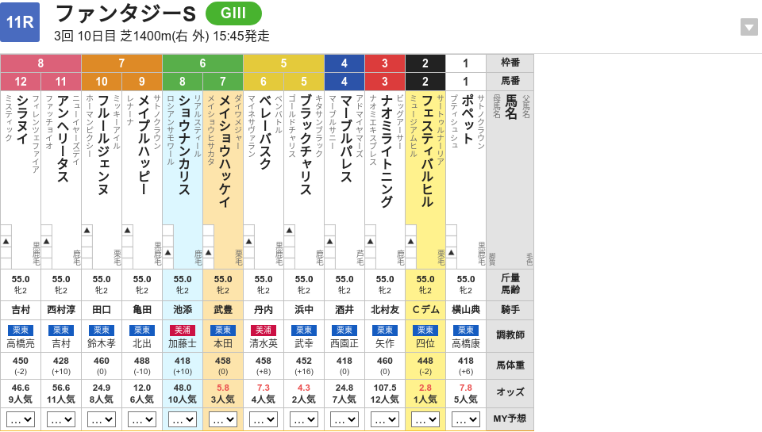

### 【天皇賞(秋) 2025/11/02(日) 】

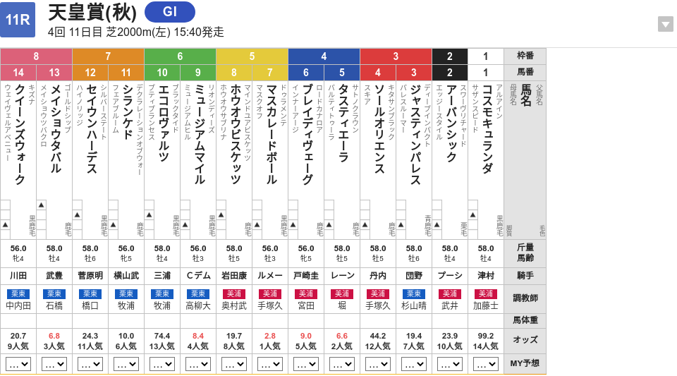

## 4. 単勝予測結果

### 【ファンタジーステークス(GⅢ) 2025/11/01(土)】

| 枠番 | 馬番 | 人気 | オッズ | 馬名 | 騎手 | 調教師 | 予測タイム(sec) | 1_順位 | 1-3着内確率(%) | 2_順位 | ﾀﾞｰｸﾎｰｽ確率(%) | 3_順位 |
| --- | --- | --- | --- | --- | --- | --- | --- | --- | --- | --- | --- | --- |
| 1 | 1 | 5 | 7.8 | ポペット | 横山典弘 | 高橋康之 | 87.2 | 5.0 | 21.3 | 3 | 1.7 | 8 |
| 2 | 2 | 1 | 2.8 | フェスティバルヒル | Ｃ．デムーロ | 四位洋文 | 80.8 | 1.0 | 18.3 | 5 | 0.5 | 11 |
| 3 | 3 | 12 | 107.5 | ナオミライトニング | 北村友一 | 矢作芳人 | 87.2 | 8.5 | 7.7 | 10 | 43.9 | 1 |
| 4 | 4 | 7 | 24.8 | マーブルパレス | 酒井学 | 西園正都 | 85.6 | 2.0 | 9.4 | 8 | 35.4 | 4 |
| 5 | 5 | 2 | 4.3 | ブラックチャリス | 浜中俊 | 武幸四郎 | 87.2 | 4.0 | 35.1 | 1 | 0.4 | 12 |
| 5 | 6 | 4 | 7.3 | ベレーバスク | 丹内祐次 | 清水英克 | 87.3 | 12.0 | 20.1 | 4 | 1.5 | 9 |
| 6 | 7 | 3 | 5.8 | メイショウハッケイ | 武豊 | 本田優 | 87.2 | 11.0 | 22.7 | 2 | 1.3 | 10 |
| 6 | 8 | 10 | 48.0 | ショウナンカリス | 池添謙一 | 加藤士津八 | 87.2 | 8.5 | 7.2 | 11 | 35.8 | 3 |
| 7 | 9 | 6 | 12.0 | メイプルハッピー | 亀田温心 | 北出成人 | 87.2 | 6.0 | 14.9 | 6 | 1.8 | 7 |
| 7 | 10 | 8 | 24.9 | フルールジェンヌ | 田口貫太 | 鈴木孝志 | 87.2 | 8.5 | 8.2 | 9 | 28.9 | 6 |

[output cut: 2 more lines]

### 【天皇賞(秋)(GⅠ) 2025/11/02(日)】

| 枠番 | 馬番 | 人気 | オッズ | 馬名 | 騎手 | 調教師 | 予測タイム(sec) | 1_順位 | 1-3着内確率(%) | 2_順位 | ﾀﾞｰｸﾎｰｽ確率(%) | 3_順位 |
| --- | --- | --- | --- | --- | --- | --- | --- | --- | --- | --- | --- | --- |
| 1 | 1 | 14 | 98.3 | コスモキュランダ | 津村明秀 | 加藤士津八 | 130.2 | 13 | 4.3 | 13 | 32.7 | 4 |
| 3 | 3 | 7 | 19.4 | ジャスティンパレス | 団野大成 | 杉山晴紀 | 127.4 | 10 | 18.4 | 7 | 1.5 | 9 |
| 3 | 4 | 12 | 43.6 | ソールオリエンス | 丹内祐次 | 手塚貴久 | 119.5 | 2 | 19.9 | 4 | 62.9 | 1 |
| 4 | 5 | 2 | 6.7 | タスティエーラ | Ｄ．レーン | 堀宣行 | 120.0 | 3 | 43.1 | 1 | 0.6 | 12 |
| 4 | 6 | 5 | 8.9 | ブレイディヴェーグ | 戸崎圭太 | 宮田敬介 | 120.3 | 4 | 20.4 | 3 | 1.8 | 7 |
| 5 | 7 | 1 | 2.8 | マスカレードボール | Ｃ．ルメール | 手塚貴久 | 116.1 | 1 | 27.5 | 2 | 0.6 | 11 |
| 5 | 8 | 8 | 19.6 | ホウオウビスケッツ | 岩田康誠 | 奥村武 | 124.2 | 7 | 7.3 | 11 | 20.4 | 6 |
| 6 | 9 | 4 | 8.6 | ミュージアムマイル | Ｃ．デムーロ | 高柳大輔 | 124.9 | 9 | 19.6 | 5 | 1.8 | 8 |
| 6 | 10 | 13 | 74.4 | エコロヴァルツ | 三浦皇成 | 牧浦充徳 | 123.8 | 6 | 10.7 | 10 | 62.3 | 2 |
| 7 | 11 | 6 | 10.0 | シランケド | 横山武史 | 牧浦充徳 | 127.6 | 11 | 12.4 | 8 | 1.4 | 10 |

[output cut: 3 more lines]

## 5. 人気と着順の乖離率推移

### 【ファンタジーステークス_1996y_2019y】

[interactive chart not shown]

### 【天皇賞_秋_1990y_2019y】

[interactive chart not shown]

### 【ファンタジーステークス_1996y_2019y】

| No | 開催年 | 不整合率(%) | 頭数 | 人気別着順(1-3位) | 人気別着順(全体) |
| --- | --- | --- | --- | --- | --- |
| 24 | 2019 | 17.3 | 15頭 | 6-1-2 | 6\|1\|2\|3\|7\|5\|12\|4\|14\|8\|13\|15\|11\|10\|9 |
| 23 | 2018 | 42.8 | 9頭 | 1-4-6 | 1\|4\|6\|5\|3\|8\|7\|2\|9 |
| 22 | 2017 | 45.0 | 13頭 | 5-3-1 | 5\|3\|1\|4\|7\|2\|6\|8\|10\|9\|11\|12\|13 |
| 21 | 2016 | 35.1 | 12頭 | 1-12-3 | 1\|12\|3\|7\|11\|5\|10\|4\|2\|9\|8\|6 |
| 20 | 2015 | 35.5 | 12頭 | 5-6-1 | 5\|6\|1\|4\|7\|2\|9\|3\|10\|8\|11\|12 |
| 19 | 2014 | 26.4 | 14頭 | 14-1-3 | 14\|1\|3\|11\|13\|2\|8\|5\|12\|10\|4\|9\|7\|6 |
| 18 | 2013 | 46.7 | 18頭 | 4-7-15 | 4\|7\|15\|1\|6\|5\|12\|3\|2\|11\|17\|9\|10\|18\|14\|13\|8\|16 |
| 17 | 2012 | 33.2 | 14頭 | 2-4-10 | 2\|4\|10\|1\|6\|7\|13\|11\|3\|5\|8\|12\|14\|9 |
| 16 | 2011 | 30.7 | 17頭 | 8-4-1 | 8\|4\|1\|11\|13\|5\|2\|3\|6\|7\|10\|12\|14\|16\|9\|15\|17 |
| 15 | 2010 | 45.8 | 17頭 | 4-7-5 | 4\|7\|5\|11\|1\|3\|13\|15\|2\|9\|6\|12\|10\|14\|8\|17\|16 |

[output cut: 14 more lines]

### 【天皇賞_秋_1990y_2019y】

| No | 開催年 | 不整合率(%) | 頭数 | 人気別着順(1-3位) | 人気別着順(全体) |
| --- | --- | --- | --- | --- | --- |
| 30 | 2019 | 27.6 | 16頭 | 1-3-6 | 1\|3\|6\|7\|4\|2\|5\|12\|14\|8\|16\|11\|10\|9\|13\|15 |
| 29 | 2018 | 54.4 | 12頭 | 2-4-6 | 2\|4\|6\|5\|8\|10\|3\|7\|9\|1\|12\|11 |
| 28 | 2017 | 13.1 | 18頭 | 1-2-13 | 1\|2\|13\|3\|9\|4\|15\|12\|6\|10\|7\|14\|8\|18\|11\|17\|16\|5 |
| 27 | 2016 | 43.7 | 15頭 | 1-7-6 | 1\|7\|6\|4\|9\|11\|3\|12\|5\|10\|14\|2\|15\|8\|13 |
| 26 | 2015 | 43.2 | 18頭 | 1-10-6 | 1\|10\|6\|5\|4\|17\|15\|3\|2\|8\|16\|9\|13\|18\|12\|11\|7\|14 |
| 25 | 2014 | 38.5 | 18頭 | 5-2-1 | 5\|2\|1\|16\|10\|4\|6\|11\|9\|12\|13\|8\|7\|3\|14\|15\|17\|18 |
| 24 | 2013 | 37.6 | 17頭 | 5-1-3 | 5\|1\|3\|8\|4\|13\|11\|7\|15\|2\|10\|9\|12\|16\|17\|6\|14 |
| 23 | 2012 | 21.8 | 18頭 | 5-1-2 | 5\|1\|2\|4\|3\|8\|16\|10\|6\|15\|13\|12\|7\|17\|14\|18\|9\|11 |
| 22 | 2011 | 31.5 | 17頭 | 7-2-6 | 7\|2\|6\|1\|10\|3\|13\|8\|9\|4\|17\|16\|18\|5\|11\|12\|14 |
| 21 | 2010 | 25.7 | 18頭 | 1-4-2 | 1\|4\|2\|17\|11\|3\|16\|13\|10\|15\|8\|14\|9\|6\|18\|12\|7\|5 |

[output cut: 20 more lines]

## 6. 1-3番人気馬の着順分類予測

### 【ファンタジーステークス】

| 分類 | 凡例 | 発生確率(%) | 当該レース | 当該レースランク | 直近1年間 |
| --- | --- | --- | --- | --- | --- |
| 4: 1,2番人気のみ (4_pop12) | 1 \| 2 \| * | 18.3 | 0.76 | 0.76 | 0.37 |
| 1: 1番人気のみ (1_pop1) | 1 \| * \| * | 17.2 | 0.83 | 0.83 | 0.00 |
| 8: 1,2,3番人気すべて着外 (8_darkhorse) | * \| * \| * | 14.5 | 2.10 | 2.10 | 0.00 |
| 5: 1,3番人気のみ (5_pop13) | 1 \| 3 \| * | 14.0 | 1.01 | 1.01 | 0.28 |
| 6: 2,3番人気のみ (6_pop23) | 2 \| 3 \| * | 9.8 | 0.95 | 0.95 | 0.00 |
| 2: 2番人気のみ (2_pop2) | 2 \| * \| * | 9.7 | 0.94 | 0.94 | 0.00 |
| 3: 3番人気のみ (3_pop3) | 3 \| * \| * | 9.5 | 0.92 | 0.92 | 0.00 |
| 7: 1,2,3番人気すべて着内 (7_pop123) | 1 \| 2 \| 3 | 7.0 | 2.06 | 2.06 | 0.00 |

### 【天皇賞(秋)】

| 分類 | 凡例 | 発生確率(%) | 当該レース | 当該レースランク | 直近1年間 |
| --- | --- | --- | --- | --- | --- |
| 4: 1,2番人気のみ (4_pop12) | 1 \| 2 \| * | 18.3 | 1.07 | 1.07 | 0.00 |
| 1: 1番人気のみ (1_pop1) | 1 \| * \| * | 17.2 | 0.86 | 0.86 | 0.00 |
| 8: 1,2,3番人気すべて着外 (8_darkhorse) | * \| * \| * | 14.5 | 1.01 | 1.01 | 0.00 |
| 5: 1,3番人気のみ (5_pop13) | 1 \| 3 \| * | 14.0 | 0.61 | 0.61 | 0.14 |
| 6: 2,3番人気のみ (6_pop23) | 2 \| 3 \| * | 9.8 | 3.38 | 3.38 | 0.00 |
| 2: 2番人気のみ (2_pop2) | 2 \| * \| * | 9.7 | 0.85 | 0.85 | 0.00 |
| 3: 3番人気のみ (3_pop3) | 3 \| * \| * | 9.5 | 1.67 | 1.67 | 0.00 |
| 7: 1,2,3番人気すべて着内 (7_pop123) | 1 \| 2 \| 3 | 7.0 | 1.23 | 1.23 | 0.00 |

## 7. 3連複予測結果

### 【ファンタジーステークス(GⅢ) 2025/11/01(土)】

| 分類 | 馬番 | 枠番 | 人気 | 平均予測タイム(sec) | 1-3着内確率(%) | ﾀﾞｰｸﾎｰｽ確率(%) | 馬名 | 騎手 | 調教師 |
| --- | --- | --- | --- | --- | --- | --- | --- | --- | --- |
| 6: 2,3番人気のみ (6_pop23) | 5-7-1 | 5-6-1 | 2-3-5 | 87.20 | 1.70 | 0.00 | ブラックチャリス \| メイショウハッケイ \| ポペット | 浜中俊 \| 武豊 \| 横山典弘 | 武幸四郎 \| 本田優 \| 高橋康之 |
| 6: 2,3番人気のみ (6_pop23) | 5-7-6 | 5-6-5 | 2-3-4 | 87.23 | 1.60 | 0.00 | ブラックチャリス \| メイショウハッケイ \| ベレーバスク | 浜中俊 \| 武豊 \| 丹内祐次 | 武幸四郎 \| 本田優 \| 清水英克 |
| 2: 2番人気のみ (2_pop2) | 5-6-1 | 5-5-1 | 2-4-5 | 87.23 | 1.50 | 0.00 | ブラックチャリス \| ベレーバスク \| ポペット | 浜中俊 \| 丹内祐次 \| 横山典弘 | 武幸四郎 \| 清水英克 \| 高橋康之 |
| 7: 1,2,3番人気すべて着内 (7_pop123) | 2-5-7 | 2-5-6 | 1-2-3 | 85.07 | 1.46 | 0.00 | フェスティバルヒル \| ブラックチャリス \| メイショウハッケイ | Ｃ．デムーロ \| 浜中俊 \| 武豊 | 四位洋文 \| 武幸四郎 \| 本田優 |
| 4: 1,2番人気のみ (4_pop12) | 2-5-1 | 2-5-1 | 1-2-5 | 85.07 | 1.37 | 0.00 | フェスティバルヒル \| ブラックチャリス \| ポペット | Ｃ．デムーロ \| 浜中俊 \| 横山典弘 | 四位洋文 \| 武幸四郎 \| 高橋康之 |
| 4: 1,2番人気のみ (4_pop12) | 2-5-6 | 2-5-5 | 1-2-4 | 85.10 | 1.29 | 0.00 | フェスティバルヒル \| ブラックチャリス \| ベレーバスク | Ｃ．デムーロ \| 浜中俊 \| 丹内祐次 | 四位洋文 \| 武幸四郎 \| 清水英克 |
| 6: 2,3番人気のみ (6_pop23) | 5-7-9 | 5-6-7 | 2-3-6 | 87.20 | 1.19 | 0.00 | ブラックチャリス \| メイショウハッケイ \| メイプルハッピー | 浜中俊 \| 武豊 \| 亀田温心 | 武幸四郎 \| 本田優 \| 北出成人 |
| 2: 2番人気のみ (2_pop2) | 5-1-9 | 5-1-7 | 2-5-6 | 87.20 | 1.12 | 0.00 | ブラックチャリス \| ポペット \| メイプルハッピー | 浜中俊 \| 横山典弘 \| 亀田温心 | 武幸四郎 \| 高橋康之 \| 北出成人 |
| 2: 2番人気のみ (2_pop2) | 5-6-9 | 5-5-7 | 2-4-6 | 87.23 | 1.05 | 0.00 | ブラックチャリス \| ベレーバスク \| メイプルハッピー | 浜中俊 \| 丹内祐次 \| 亀田温心 | 武幸四郎 \| 清水英克 \| 北出成人 |
| 3: 3番人気のみ (3_pop3) | 7-6-1 | 6-5-1 | 3-4-5 | 87.23 | 0.97 | 0.00 | メイショウハッケイ \| ベレーバスク \| ポペット | 武豊 \| 丹内祐次 \| 横山典弘 | 本田優 \| 清水英克 \| 高橋康之 |

[output cut: 210 more lines]

### 【天皇賞(秋)(GⅠ) 2025/11/02(日)】

| 分類 | 馬番 | 枠番 | 人気 | 平均予測タイム(sec) | 1-3着内確率(%) | ﾀﾞｰｸﾎｰｽ確率(%) | 馬名 | 騎手 | 調教師 |
| --- | --- | --- | --- | --- | --- | --- | --- | --- | --- |
| 4: 1,2番人気のみ (4_pop12) | 7-5-6 | 5-4-4 | 1-2-5 | 118.80 | 2.43 | 0.00 | マスカレードボール \| タスティエーラ \| ブレイディヴェーグ | Ｃ．ルメール \| Ｄ．レーン \| 戸崎圭太 | 手塚貴久 \| 堀宣行 \| 宮田敬介 |
| 4: 1,2番人気のみ (4_pop12) | 7-5-4 | 5-4-3 | 1-2-12 | 118.53 | 2.36 | 0.00 | マスカレードボール \| タスティエーラ \| ソールオリエンス | Ｃ．ルメール \| Ｄ．レーン \| 丹内祐次 | 手塚貴久 \| 堀宣行 \| 手塚貴久 |
| 4: 1,2番人気のみ (4_pop12) | 7-5-9 | 5-4-6 | 1-2-4 | 120.33 | 2.32 | 0.00 | マスカレードボール \| タスティエーラ \| ミュージアムマイル | Ｃ．ルメール \| Ｄ．レーン \| Ｃ．デムーロ | 手塚貴久 \| 堀宣行 \| 高柳大輔 |
| 7: 1,2,3番人気すべて着内 (7_pop123) | 7-5-13 | 5-4-8 | 1-2-3 | 120.20 | 2.20 | 0.00 | マスカレードボール \| タスティエーラ \| メイショウタバル | Ｃ．ルメール \| Ｄ．レーン \| 武豊 | 手塚貴久 \| 堀宣行 \| 石橋守 |
| 4: 1,2番人気のみ (4_pop12) | 7-5-3 | 5-4-3 | 1-2-7 | 121.17 | 2.19 | 0.00 | マスカレードボール \| タスティエーラ \| ジャスティンパレス | Ｃ．ルメール \| Ｄ．レーン \| 団野大成 | 手塚貴久 \| 堀宣行 \| 杉山晴紀 |
| 2: 2番人気のみ (2_pop2) | 5-6-4 | 4-4-3 | 2-5-12 | 119.93 | 1.76 | 0.01 | タスティエーラ \| ブレイディヴェーグ \| ソールオリエンス | Ｄ．レーン \| 戸崎圭太 \| 丹内祐次 | 堀宣行 \| 宮田敬介 \| 手塚貴久 |
| 2: 2番人気のみ (2_pop2) | 5-9-6 | 4-6-4 | 2-4-5 | 121.73 | 1.73 | 0.00 | タスティエーラ \| ミュージアムマイル \| ブレイディヴェーグ | Ｄ．レーン \| Ｃ．デムーロ \| 戸崎圭太 | 堀宣行 \| 高柳大輔 \| 宮田敬介 |
| 2: 2番人気のみ (2_pop2) | 5-9-4 | 4-6-3 | 2-4-12 | 121.47 | 1.68 | 0.01 | タスティエーラ \| ミュージアムマイル \| ソールオリエンス | Ｄ．レーン \| Ｃ．デムーロ \| 丹内祐次 | 堀宣行 \| 高柳大輔 \| 手塚貴久 |
| 6: 2,3番人気のみ (6_pop23) | 5-13-6 | 4-8-4 | 2-3-5 | 121.60 | 1.63 | 0.00 | タスティエーラ \| メイショウタバル \| ブレイディヴェーグ | Ｄ．レーン \| 武豊 \| 戸崎圭太 | 堀宣行 \| 石橋守 \| 宮田敬介 |
| 2: 2番人気のみ (2_pop2) | 5-6-3 | 4-4-3 | 2-5-7 | 122.57 | 1.63 | 0.00 | タスティエーラ \| ブレイディヴェーグ \| ジャスティンパレス | Ｄ．レーン \| 戸崎圭太 \| 団野大成 | 堀宣行 \| 宮田敬介 \| 杉山晴紀 |

[output cut: 210 more lines]

## 8. 直近の全レース情報

[output not shown]